# R Bootcamp

# Welcome!

Welcome to your self-guided tour through David Degnan/Lisa Bramer’s R and Python Bootcamp for data science! We are data scientists at Pacific Northwest National Laboratory and bioinformatics/biostatistics professors at the University of Oregon. This lecture series has been adapted from several R/Python teaching workshops. If you experience any issues, please reach out to David at david.degnan@pnnl.gov

*More about the authors:* [David Degnan](https://www.pnnl.gov/people/david-degnan), [Lisa Bramer](https://www.pnnl.gov/people/lisa-bramer)

## How does this work?

You are currently in a jupyter notebook. These notebooks are divided into two sections. A text section (which you are currently reading) and a code section (examples below). Code sections allow you to run code by hitting the play button. You may write your own code in these sections too. Note that you are on your own notebook server at this moment, which means no one else can access/see what you are doing. It also means you are free to play with any code you want to, and you will not mess up other folks’ notebooks. It does mean that any notes you type in here will not be saved, so write them elsewhere. This notebook is in R and contains the R introductory tutorials.

# R Lecture 1: R Objects

In practice, we typically install R and RStudio on our computers and use RStudio to code. But for now, let’s use google collab. A key first step when using R is to determine the version you’re using. So let’s start with that!

```r
# This actually returns a list (more later) and we can access values in a list with a $
R.Version()$version.string
```

```
## [1] "R version 4.5.0 (2025-04-11)"
```

## Section 1.1 Single Values

Let’s learn about the individual object types available in R. At a base level, one can think of R as a fancy calculator. It does the basic operations of a calculator, and even follows the rules of PEMDAS (Parenthesis, Exponent, Multiplication and Division, Addition and Subtraction). Whenever you hand code an equation, remember PEMDAS! It is a common mistake of early programmers. In this code, we have put a comment before the code using the pound sign (#).

```r
# Multiply 199 by 3, add 100, divide by 4
(199*3 + 100) / 4
```

```
## [1] 174.25
```

```r
# Take the log base 2 of a value
log2(8)
```

```
## [1] 3
```

```r
# Note that log by itself is base log, so pay attention to the base when using log functions
log(8)
```

```
## [1] 2.079442
```

```r
# Take a square root
sqrt(16)
```

```
## [1] 4
```

In R, there are also *comparison* functions. Think greater than (>), greater than or equal to (>=), equal to (==), etc.

```r
# Is 1 greater than 2?
1 > 2
```

```
## [1] FALSE
```

Note that what is returned is a logical - a TRUE or FALSE to indicate whether the comparison is correct (TRUE) or incorrect (FALSE).

```r
# Is 2 greater than or equal to 2?
2 >= 2
```

```
## [1] TRUE
```

```r
# Is 2 equal to 2?
2 == 2
```

```
## [1] TRUE
```

```r
# Is 3 less than 2?
3 < 2
```

```
## [1] FALSE
```

```r
# Is 3 less than or equal to 2?
3 <= 2
```

```
## [1] FALSE
```

You can assign a value to a variable with “=”, which is different from “==” which determines whether two values are equivalent to each other or not.

```r
# In R, you can assign a variable's value with "="
my_var = 5

# And call it by simply typing the name of the variable
my_var
```

```
## [1] 5
```

```r
# In R, you can also assign values with an arrow (<-), though most programmers
# are starting to move away from this older implementation
this_works_too <- 10

this_works_too
```

```
## [1] 10
```

R has many object types. Here are some of the main ones and the functions to make them:

*Character:* a type to hold text values, also called strings `x = "words"`

*Logical:* a type to store TRUEs and FALSEs `x=FALSE` or `x=F`. Note that `x="False"` will store the value as a string and not a logical.

*Factor:* a special R type of strings with an inherent order. Think: low, medium, high. `x=factor("low", "medium", "high")`

*Numeric:* a number `x=1`

```r
# Let's investigate the character objects
cat_var = "cats"

# We can get the object type with the class() function
class(cat_var)
```

```
## [1] "character"
```

```r
# Logical
x = TRUE
class(x)
```

```
## [1] "logical"
```

```r
# Factor - note that the variable "x" has now been overwritten with my new
# variable call
x = factor("low")
class(x)
```

```
## [1] "factor"
```

```r
# Numeric
x = 1
class(x)
```

```
## [1] "numeric"
```

```r
# Special numeric type - integers
x = integer(1)
class(x)
```

```
## [1] "integer"
```

```r
# Special type - NA can be used for any missing data (very important and common in data science)
NA
```

```
## [1] NA
```

```r
class(NA) # It's actually the logical type!
```

```
## [1] "logical"
```

```r
# Special type - Infinity
1/0
```

```
## [1] Inf
```

```r
class(1/0) # It's the numeric type, which makes sense
```

```
## [1] "numeric"
```

```r
# Special type - NaN "not a number"
0/0
```

```
## [1] NaN
```

```r
class(0/0)
```

```
## [1] "numeric"
```

## Section 1.2 Multiple Values

If you are more familiar with python or R, this list of comparisons between objects which allow multiple values may be helpful. If not, no worries. We will go through each of these object types.

| **Python** | **R** |
| --- | --- |
| **List** | **Vector** |
| **Dictionary** | **List** |
| **DataFrame** (`pandas`) | **data.frame** (`tibble`, `data.frame`, `data.table`) |
| **2D Array/Matrix** (`numpy`) | **matrix** (mostly used for matrix math) |

*Vectors* are a series of objects in R. Vectors are *atomic*, meaning they must all the be same type. You can set a vector in R use `c()` or `:`.

```r
# Make a vector of strings
c("cat", "dog", "rabbit")
```

```
## [1] "cat"    "dog"    "rabbit"
```

```r
# Make a vector of numbers
1:6
```

```
## [1] 1 2 3 4 5 6
```

```r
# The seq function can be used to make other arrangements of number vectors
# (like counting by halves)
seq(1, 3, 0.5)
```

```
## [1] 1.0 1.5 2.0 2.5 3.0
```

```r
# R has some built-in vectors, like the entire alphabet
LETTERS
```

```
##  [1] "A" "B" "C" "D" "E" "F" "G" "H" "I" "J" "K" "L" "M" "N" "O" "P" "Q" "R" "S"
## [20] "T" "U" "V" "W" "X" "Y" "Z"
```

```r
# Vectors can be one type, and there is a hierarchy to types in R. If a string
# is included in a vector, it will convert the entire vector to string.
c(1, "2", 3)
```

```
## [1] "1" "2" "3"
```

```r
class(c(1, "2", 3))
```

```
## [1] "character"
```

```r
# You can append a vector to another vector
my_vec = 1:3
my_vec2 = c(4:6)
c(my_vec, my_vec2)
```

```
## [1] 1 2 3 4 5 6
```

```r
# You can also query a vector. This will return the 3rd letter. Unlike python,
# R starts counting at index 1 (as opposed to index 0).
LETTERS[3]
```

```
## [1] "C"
```

```r
# Remove a value with -
  LETTERS[-3]
```

```
##  [1] "A" "B" "D" "E" "F" "G" "H" "I" "J" "K" "L" "M" "N" "O" "P" "Q" "R" "S" "T"
## [20] "U" "V" "W" "X" "Y" "Z"
```

```r
# Be careful with the minus and a vector. To remove multiple letters, do this
LETTERS[-c(3:26)]
```

```
## [1] "A" "B"
```

```r
# As opposed to this: LETTERS[-3:26]
# It includes a zero which is not a valid index value
```

Note that several function in R are *vectorized* and iterate through a vector automatically. For example:

```r
# The vector 3:6 is iterated through and TRUEs/FALSEs are returned where the
# instances are TRUE or FALSE. This is because >= is vectorized.
# Not every function in R is vectorized!
3:6 > 4
```

```
## [1] FALSE FALSE  TRUE  TRUE
```

Like vectors, elements (another word for values) in a *matrix* must be of the same type. The `nrow` and `ncol` parameters will set the number of rows and columns. Matrices are sometimes used in R, oftentimes to make slower code fast. It is more common to use `data.frames` which we will cover shortly.

```r
# Specification of rows and columns matters
matrix(1:10, nrow = 2, ncol = 5)
```

```
##      [,1] [,2] [,3] [,4] [,5]
## [1,]    1    3    5    7    9
## [2,]    2    4    6    8   10
```

```r
# Specification of rows and columns matters
matrix(1:10, nrow = 5, ncol = 2)
```

```
##      [,1] [,2]
## [1,]    1    6
## [2,]    2    7
## [3,]    3    8
## [4,]    4    9
## [5,]    5   10
```

```r
# Matrices are queried by row then column [row, column]
mymatrix = matrix(1:10, nrow = 5, ncol = 2)
mymatrix[1,2]
```

```
## [1] 6
```

```r
# If you want the entire row, leave the column selection blank
mymatrix[1,]
```

```
## [1] 1 6
```

```r
# If you want the entire column, leave the row selection blank
mymatrix[,2]
```

```
## [1]  6  7  8  9 10
```

R does not do matrix math by default, and requires special implementations of the math functions to do so.

```r
matA = matrix(1:4, nrow = 2)
matB = matrix(5:8, nrow = 2)

# Each value of A is multiplied to B, which is not matrix math
matA * matB
```

```
##      [,1] [,2]
## [1,]    5   21
## [2,]   12   32
```

```r
# Here is the correct form for matrix math. If needed, google the other functions.
matA %*% matB
```

```
##      [,1] [,2]
## [1,]   23   31
## [2,]   34   46
```

*Lists* are very flexible R objects. Elements in a list do NOT have to be of the same type or even of the same data structure.

```r
# Look at this complicated list! It has vectors, it has lists, with data.frames
# inside it. Holy cow!
mylist = list(
  Participants = c("Anna", "Bill", "Cora", "Dean"),
  RaceDate = format(Sys.Date(), "%a %b %d"),
  Distances = c("5k", "10k"),
  Results = list("5k" = data.frame(Name = c("Dean", "Edward"),
                                   RaceTime = c(29.02, 30.24)),
                 "10k" = data.frame(Name = c("Anna", "Bill", "Cora"),
                                    RaceTime = c(59.1, 62.42, 60.59))
            )
)
mylist
```

```
## $Participants
## [1] "Anna" "Bill" "Cora" "Dean"
##
## $RaceDate
## [1] "Wed Dec 31"
##
## $Distances
## [1] "5k"  "10k"
##
## $Results
## $Results$`5k`
##     Name RaceTime
## 1   Dean    29.02
## 2 Edward    30.24
##
## $Results$`10k`
##   Name RaceTime
## 1 Anna    59.10
## 2 Bill    62.42
## 3 Cora    60.59
```

```r
# Access values in a list with double brackets [[]] or the $

# Return the first entry in the list
mylist[[1]]
```

```
## [1] "Anna" "Bill" "Cora" "Dean"
```

```r
# Return the entry called "Participants"
mylist$Participants
```

```
## [1] "Anna" "Bill" "Cora" "Dean"
```

```r
# Return the 4th entry (a list) and extract the first entry of that list
mylist[[4]][[1]]
```

```
##     Name RaceTime
## 1   Dean    29.02
## 2 Edward    30.24
```

```r
# Use backticks to access strange names in lists. R doesn't like names that
# start with numbers or has spaces. Backticks is your friend in these cases.
mylist[[4]]$`5k`
```

```
##     Name RaceTime
## 1   Dean    29.02
## 2 Edward    30.24
```

A *data.frame* is an organized list where each vector within the data.frame has the same length. It is essentially a table. This is the “bread and butter” object of data science and several of the functions we are going to teach you.

```r
# How to make a data.frame
mydataframe = data.frame(
  Name = c("Anna", "Bill", "Cora", "Dean"),
  Age = c(29, 37, 60, 42),
  Sex = c("F", "M", "F", "M"),
  Employed = c(TRUE, TRUE, FALSE, TRUE)
)

mydataframe
```

```
##   Name Age Sex Employed
## 1 Anna  29   F     TRUE
## 2 Bill  37   M     TRUE
## 3 Cora  60   F    FALSE
## 4 Dean  42   M     TRUE
```

```r
# data.frames are their own class of object. They are essentially
# special lists with extra rules.
class(mydataframe)
```

```
## [1] "data.frame"
```

```r
# You can check any object's type with the `is` functions
is.data.frame(mydataframe)
```

```
## [1] TRUE
```

```r
is.list(mydataframe)
```

```
## [1] TRUE
```

```r
# You can convert them with the `as` functions
as.list(mydataframe)
```

```
## $Name
## [1] "Anna" "Bill" "Cora" "Dean"
##
## $Age
## [1] 29 37 60 42
##
## $Sex
## [1] "F" "M" "F" "M"
##
## $Employed
## [1]  TRUE  TRUE FALSE  TRUE
```

```r
# Query a data.frame like we query a matrix - row, then column
mydataframe[1:4, 2]
```

```
## [1] 29 37 60 42
```

```r
# Or by using names
mydataframe[,"Age"]
```

```
## [1] 29 37 60 42
```

```r
# Or by using $, as with lists
mydataframe$Age
```

```
## [1] 29 37 60 42
```

Similar to *data.frames* are *data.tables* which are faster data.frames from the `data.tables` package, and *tibbles* which were a precursor to data.frames, but are still widely used, especially with the tidyverse functions we will learn later.

## Section 1.3 Hidden Values

A powerful way to “hide” information about R objects. Used often in package design. Attributes can be any R object, like lists, dimensions, column names, logicals. They are used more often in advanced R programming, and can help speed up slow code or keep track of a lot of information in one place.

```r
# Here are some hidden attributes for our dataframe
attributes(mydataframe)
```

```
## $names
## [1] "Name"     "Age"      "Sex"      "Employed"
##
## $class
## [1] "data.frame"
##
## $row.names
## [1] 1 2 3 4
```

```r
# They can be accessed with functions
colnames(mydataframe)
```

```
## [1] "Name"     "Age"      "Sex"      "Employed"
```

```r
row.names(mydataframe)
```

```
## [1] "1" "2" "3" "4"
```

```r
names(mydataframe)
```

```
## [1] "Name"     "Age"      "Sex"      "Employed"
```

```r
# Or with $
attributes(mydataframe)$class
```

```
## [1] "data.frame"
```

```r
# You can also add your own!
attributes(mydataframe)$Tacos = "Delicious"
attributes(mydataframe)
```

```
## $names
## [1] "Name"     "Age"      "Sex"      "Employed"
##
## $class
## [1] "data.frame"
##
## $row.names
## [1] 1 2 3 4
##
## $Tacos
## [1] "Delicious"
```

# R Lecture 2: Basic R Functions

R has some basic functions built-in to the base package of the language. The base package is the one that is loaded when you start R. Let’s learn about some of these functions

## Section 2.1 Basic Matrix/Data.Frame Functions

The `iris` dataset is one that is baked into base R, and one we will use a lot. Let’s learn about it.

```r
# dim() gives the dimensions. R is always row then column.
dim(iris)
```

```
## [1] 150   5
```

```r
# Get the number of rows with nrow()
nrow(iris)
```

```
## [1] 150
```

```r
# Get the number of columns with ncol()
ncol(iris)
```

```
## [1] 5
```

```r
# See the first few rows with head
head(iris)
```

```
##   Sepal.Length Sepal.Width Petal.Length Petal.Width Species
## 1          5.1         3.5          1.4         0.2  setosa
## 2          4.9         3.0          1.4         0.2  setosa
## 3          4.7         3.2          1.3         0.2  setosa
## 4          4.6         3.1          1.5         0.2  setosa
## 5          5.0         3.6          1.4         0.2  setosa
## 6          5.4         3.9          1.7         0.4  setosa
```

```r
# And the last few rows with tail
tail(iris)
```

```
##     Sepal.Length Sepal.Width Petal.Length Petal.Width   Species
## 145          6.7         3.3          5.7         2.5 virginica
## 146          6.7         3.0          5.2         2.3 virginica
## 147          6.3         2.5          5.0         1.9 virginica
## 148          6.5         3.0          5.2         2.0 virginica
## 149          6.2         3.4          5.4         2.3 virginica
## 150          5.9         3.0          5.1         1.8 virginica
```

```r
# You can do more complicated row selection with vectorization
# The F/T is iterated through the data.frame, returning just
# the even rows. Let's look at a few with head().
head(iris[c(FALSE, TRUE),])
```

```
##    Sepal.Length Sepal.Width Petal.Length Petal.Width Species
## 2           4.9         3.0          1.4         0.2  setosa
## 4           4.6         3.1          1.5         0.2  setosa
## 6           5.4         3.9          1.7         0.4  setosa
## 8           5.0         3.4          1.5         0.2  setosa
## 10          4.9         3.1          1.5         0.1  setosa
## 12          4.8         3.4          1.6         0.2  setosa
```

```r
# The selection can get quite complicated!
head(iris[c(F,F,T,F,T),])
```

```
##    Sepal.Length Sepal.Width Petal.Length Petal.Width Species
## 3           4.7         3.2          1.3         0.2  setosa
## 5           5.0         3.6          1.4         0.2  setosa
## 8           5.0         3.4          1.5         0.2  setosa
## 10          4.9         3.1          1.5         0.1  setosa
## 13          4.8         3.0          1.4         0.1  setosa
## 15          5.8         4.0          1.2         0.2  setosa
```

```r
# Learn some high level summary information with summary().
# We get statistics for the continuous variables, and counts
# for the categorical.
summary(iris)
```

```
##   Sepal.Length    Sepal.Width     Petal.Length    Petal.Width
##  Min.   :4.300   Min.   :2.000   Min.   :1.000   Min.   :0.100
##  1st Qu.:5.100   1st Qu.:2.800   1st Qu.:1.600   1st Qu.:0.300
##  Median :5.800   Median :3.000   Median :4.350   Median :1.300
##  Mean   :5.843   Mean   :3.057   Mean   :3.758   Mean   :1.199
##  3rd Qu.:6.400   3rd Qu.:3.300   3rd Qu.:5.100   3rd Qu.:1.800
##  Max.   :7.900   Max.   :4.400   Max.   :6.900   Max.   :2.500
##        Species
##  setosa    :50
##  versicolor:50
##  virginica :50
##
##
##
```

```r
# Transpose a table (flip rows and columns) with t
t(iris)[1:5, 1:5] # Let's look at a few entries
```

```
##              [,1]     [,2]     [,3]     [,4]     [,5]
## Sepal.Length "5.1"    "4.9"    "4.7"    "4.6"    "5.0"
## Sepal.Width  "3.5"    "3.0"    "3.2"    "3.1"    "3.6"
## Petal.Length "1.4"    "1.4"    "1.3"    "1.5"    "1.4"
## Petal.Width  "0.2"    "0.2"    "0.2"    "0.2"    "0.2"
## Species      "setosa" "setosa" "setosa" "setosa" "setosa"
```

## Section 2.2 Basic Statistics

```r
# Add values together with sum. Let's add all the Sepal.Lengths together
sum(iris$Sepal.Length)
```

```
## [1] 876.5
```

```r
# We can also do some basic counting by converting to logical. Let's count
# number of Sepal.Lengths above 5.
sum(iris$Sepal.Length > 5)
```

```
## [1] 118
```

```r
# We can also count the number of missing values
sum(is.na(iris$Sepal.Length)) # No missingness!
```

```
## [1] 0
```

```r
# To take a measurement of center, use mean or median
mean(iris$Sepal.Length)
```

```
## [1] 5.843333
```

```r
median(iris$Sepal.Length)
```

```
## [1] 5.8
```

```r
# You can get the variance and standard deviation to determine
# how much data deviates from that center
var(iris$Sepal.Length)
```

```
## [1] 0.6856935
```

```r
sd(iris$Sepal.Length)
```

```
## [1] 0.8280661
```

```r
# Sometimes there's too many digits, and you'd prefere to round
round(sd(iris$Sepal.Length), digits = 4)
```

```
## [1] 0.8281
```

```r
# You can also round up to the whole number
ceiling(0.8281)
```

```
## [1] 1
```

```r
# Or down
floor(0.8281)
```

```
## [1] 0
```

```r
# You can also calculate the correlation between two values
cor(iris$Sepal.Length, iris$Sepal.Width)
```

```
## [1] -0.1175698
```

## Section 2.3 Other Basic Functions

```r
# Sort a vector with sort
sort(iris$Sepal.Length)
```

```
##   [1] 4.3 4.4 4.4 4.4 4.5 4.6 4.6 4.6 4.6 4.7 4.7 4.8 4.8 4.8 4.8 4.8 4.9 4.9
##  [19] 4.9 4.9 4.9 4.9 5.0 5.0 5.0 5.0 5.0 5.0 5.0 5.0 5.0 5.0 5.1 5.1 5.1 5.1
##  [37] 5.1 5.1 5.1 5.1 5.1 5.2 5.2 5.2 5.2 5.3 5.4 5.4 5.4 5.4 5.4 5.4 5.5 5.5
##  [55] 5.5 5.5 5.5 5.5 5.5 5.6 5.6 5.6 5.6 5.6 5.6 5.7 5.7 5.7 5.7 5.7 5.7 5.7
##  [73] 5.7 5.8 5.8 5.8 5.8 5.8 5.8 5.8 5.9 5.9 5.9 6.0 6.0 6.0 6.0 6.0 6.0 6.1
##  [91] 6.1 6.1 6.1 6.1 6.1 6.2 6.2 6.2 6.2 6.3 6.3 6.3 6.3 6.3 6.3 6.3 6.3 6.3
## [109] 6.4 6.4 6.4 6.4 6.4 6.4 6.4 6.5 6.5 6.5 6.5 6.5 6.6 6.6 6.7 6.7 6.7 6.7
## [127] 6.7 6.7 6.7 6.7 6.8 6.8 6.8 6.9 6.9 6.9 6.9 7.0 7.1 7.2 7.2 7.2 7.3 7.4
## [145] 7.6 7.7 7.7 7.7 7.7 7.9
```

```r
# You can also change the direction
sort(iris$Sepal.Length, decreasing = TRUE)
```

```
##   [1] 7.9 7.7 7.7 7.7 7.7 7.6 7.4 7.3 7.2 7.2 7.2 7.1 7.0 6.9 6.9 6.9 6.9 6.8
##  [19] 6.8 6.8 6.7 6.7 6.7 6.7 6.7 6.7 6.7 6.7 6.6 6.6 6.5 6.5 6.5 6.5 6.5 6.4
##  [37] 6.4 6.4 6.4 6.4 6.4 6.4 6.3 6.3 6.3 6.3 6.3 6.3 6.3 6.3 6.3 6.2 6.2 6.2
##  [55] 6.2 6.1 6.1 6.1 6.1 6.1 6.1 6.0 6.0 6.0 6.0 6.0 6.0 5.9 5.9 5.9 5.8 5.8
##  [73] 5.8 5.8 5.8 5.8 5.8 5.7 5.7 5.7 5.7 5.7 5.7 5.7 5.7 5.6 5.6 5.6 5.6 5.6
##  [91] 5.6 5.5 5.5 5.5 5.5 5.5 5.5 5.5 5.4 5.4 5.4 5.4 5.4 5.4 5.3 5.2 5.2 5.2
## [109] 5.2 5.1 5.1 5.1 5.1 5.1 5.1 5.1 5.1 5.1 5.0 5.0 5.0 5.0 5.0 5.0 5.0 5.0
## [127] 5.0 5.0 4.9 4.9 4.9 4.9 4.9 4.9 4.8 4.8 4.8 4.8 4.8 4.7 4.7 4.6 4.6 4.6
## [145] 4.6 4.5 4.4 4.4 4.4 4.3
```

```r
# You can also find the position where a value matches
match(4.4, iris$Sepal.Length) # It will return the first match
```

```
## [1] 9
```

```r
iris$Sepal.Length[9]
```

```
## [1] 4.4
```

```r
# Which will return all positions where the statement is TRUE
which(iris$Sepal.Length == 4.4)
```

```
## [1]  9 39 43
```

```r
# Any will return TRUE if anything in a vector is true
any(c(T,F,F,F))
```

```
## [1] TRUE
```

```r
# All will return TRUE if everything in the vector is true
all(c(T,F,F,F))
```

```
## [1] FALSE
```

```r
# Subset will return rows where a statement is true
head(subset(iris, Species == "setosa"))
```

```
##   Sepal.Length Sepal.Width Petal.Length Petal.Width Species
## 1          5.1         3.5          1.4         0.2  setosa
## 2          4.9         3.0          1.4         0.2  setosa
## 3          4.7         3.2          1.3         0.2  setosa
## 4          4.6         3.1          1.5         0.2  setosa
## 5          5.0         3.6          1.4         0.2  setosa
## 6          5.4         3.9          1.7         0.4  setosa
```

```r
# %in% will return TRUE if a value is in something
"setosa" %in% iris$Species
```

```
## [1] TRUE
```

```r
# If-else will evaluate a statement, returning what is in the IF statement
# when the condition is TRUE, otherwise, it returns what is in the ELSE
# statement.
if ("setosa" %in% iris$Species){

  message("setosa is in the species data.frame")

} else{

  message("This message should never display.")
}
```

```
## setosa is in the species data.frame
```

```r
# ifelse is a vectorized version
ifelse(1:5 > 2, "> 2", "< 3")
```

```
## [1] "< 3" "< 3" "> 2" "> 2" "> 2"
```

# R Lecture 3: Data Manipulation

In R, there are several packages with functions. The order you load packages in matters, which means functions from later packages, loaded with a `library()` call, may overwrite earlier functions. Thus, sometimes we have to specify the package and function like so `package::function()`. For example, the `select()` function from the `dplyr` package could be written as so `dplyr::select()`.

Here, let’s learn some basic of data manipulation.

Though it sounds simplistic, understanding the difference between “wide” and “long” format is fundamental to understanding data science in R. All common tidyverse packages, which is the highly popular suite of R packages for managing data, will require some switching from long to wide format and vice versa. So let’s learn that now.

|  | **Wide Format** | **Long Format** |
| --- | --- | --- |
| **Human Readable** | Tables are smaller and easier to read | Tables are longer and harder to read |
| **Size** | Tends to be smaller | Tends to be larger |
| **Computer Readable** | Slower to process computationally | Faster to process computationally |

## Section 3.1 Long and Wide Format

```r
# Iris is currently in wide format, where we have multiple variable measurements
# per species, and each variable is a column. Let's add an ID for each measurement.
iris2 = iris
iris2$ID = 1:nrow(iris2)
head(iris2)
```

```
##   Sepal.Length Sepal.Width Petal.Length Petal.Width Species ID
## 1          5.1         3.5          1.4         0.2  setosa  1
## 2          4.9         3.0          1.4         0.2  setosa  2
## 3          4.7         3.2          1.3         0.2  setosa  3
## 4          4.6         3.1          1.5         0.2  setosa  4
## 5          5.0         3.6          1.4         0.2  setosa  5
## 6          5.4         3.9          1.7         0.4  setosa  6
```

```r
# Let's load the tidyverse. When running scripts in Rstudio, you will have to
# install with `install.packages()`. This package is already installed for you here.
library(tidyverse)
# Let's pivot those first four columns longer
# Now we have a new data.frame with species, name (the names of the columns with
# pivoted) and value (those columns' values)
long = pivot_longer(iris2, cols = 1:4)
head(long)
```

```
## # A tibble: 6 × 4
##   Species    ID name         value
##   <fct>   <int> <chr>        <dbl>
## 1 setosa      1 Sepal.Length   5.1
## 2 setosa      1 Sepal.Width    3.5
## 3 setosa      1 Petal.Length   1.4
## 4 setosa      1 Petal.Width    0.2
## 5 setosa      2 Sepal.Length   4.9
## 6 setosa      2 Sepal.Width    3
```

```r
# To pivot back, let's use pivot_wider. Here, the id_cols are the columns
# with the identifiers, names are the new column names, and values are where
# the column values are from.
head(pivot_wider(long, id_cols = c(ID, Species), names_from = name, values_from = value))
```

```
## # A tibble: 6 × 6
##      ID Species Sepal.Length Sepal.Width Petal.Length Petal.Width
##   <int> <fct>          <dbl>       <dbl>        <dbl>       <dbl>
## 1     1 setosa           5.1         3.5          1.4         0.2
## 2     2 setosa           4.9         3            1.4         0.2
## 3     3 setosa           4.7         3.2          1.3         0.2
## 4     4 setosa           4.6         3.1          1.5         0.2
## 5     5 setosa           5           3.6          1.4         0.2
## 6     6 setosa           5.4         3.9          1.7         0.4
```

## Section 3.2 Joins

```r
# Let's define two tables with information to join
Cost = data.frame(
  Item = c("Waffles", "Pancakes", "Bacon", "Biscuits"),
  UnitCost = c(0.25, 0.25, 1.00, 0.50)
)
Cost
```

```
##       Item UnitCost
## 1  Waffles     0.25
## 2 Pancakes     0.25
## 3    Bacon     1.00
## 4 Biscuits     0.50
```

```r
Sales = data.frame(
  Location = c(rep("Eugene", 3), rep("Springfield", 2)),
  Item = c("Pancakes", "Bacon", "Sausage", "Waffles", "Pancakes"),
  UnitSales = c(5, 2, 4, 5, 4)
)
Sales
```

```
##      Location     Item UnitSales
## 1      Eugene Pancakes         5
## 2      Eugene    Bacon         2
## 3      Eugene  Sausage         4
## 4 Springfield  Waffles         5
## 5 Springfield Pancakes         4
```

```r
# Let's join everything that matches in the "Item" category from Sales
# to Cost, but let's not lose anything in Cost. Though no Biscuits were
# sold, it's still in this data.frame, and returned as "NA". In other
# words, it's missing.
left_join(Cost, Sales, by = "Item")
```

```
##       Item UnitCost    Location UnitSales
## 1  Waffles     0.25 Springfield         5
## 2 Pancakes     0.25      Eugene         5
## 3 Pancakes     0.25 Springfield         4
## 4    Bacon     1.00      Eugene         2
## 5 Biscuits     0.50        <NA>        NA
```

```r
# Let's do that again, but this time, keep everything in Sales.
# Sausages were sold, but we don't know what they cost, thus
# that value is NA.
right_join(Cost, Sales, by = "Item")
```

```
##       Item UnitCost    Location UnitSales
## 1  Waffles     0.25 Springfield         5
## 2 Pancakes     0.25      Eugene         5
## 3 Pancakes     0.25 Springfield         4
## 4    Bacon     1.00      Eugene         2
## 5  Sausage       NA      Eugene         4
```

```r
# Let's do that again, but instead, remove anything missing.
inner_join(Cost, Sales, by = "Item")
```

```
##       Item UnitCost    Location UnitSales
## 1  Waffles     0.25 Springfield         5
## 2 Pancakes     0.25      Eugene         5
## 3 Pancakes     0.25 Springfield         4
## 4    Bacon     1.00      Eugene         2
```

```r
# Let's do that one more time, but keep every mismatch
full_join(Cost, Sales, by = "Item")
```

```
##       Item UnitCost    Location UnitSales
## 1  Waffles     0.25 Springfield         5
## 2 Pancakes     0.25      Eugene         5
## 3 Pancakes     0.25 Springfield         4
## 4    Bacon     1.00      Eugene         2
## 5 Biscuits     0.50        <NA>        NA
## 6  Sausage       NA      Eugene         4
```

# R Lecture 4: Data Science Language

We are now ready to start learning the tidyverse! Make sure the tidyverse is loaded by typing `library(tidyverse)` and running it at least once in a code chunk. You should be fine if you’re following along, but if you skipped to this section, you’ll need to load this library first.

## Section 4.1 grep functions

Sometimes, we need to do complicated string matching with [regex](https://rstudio.github.io/cheatsheets/regex.pdf). The `grep` functions are a way for us to use this regex functionality. We will not exhaustively demonstrate regex, but rather, provide a few examples.

```r
# As a reminder, here is what the letters vector looks like
letters
```

```
##  [1] "a" "b" "c" "d" "e" "f" "g" "h" "i" "j" "k" "l" "m" "n" "o" "p" "q" "r" "s"
## [20] "t" "u" "v" "w" "x" "y" "z"
```

```r
# Let's return the positions of a-c
grep(pattern = "[a-c]", letters)
```

```
## [1] 1 2 3
```

```r
# Let's return the positions of all the vowels
grep("a|e|i|o|u", letters)
```

```
## [1]  1  5  9 15 21
```

```r
# grepl, "grep logical", will instead return a TRUE/FALSE (logical) vector
# as opposed to the positions
grepl(pattern = "[a-c]", letters)
```

```
##  [1]  TRUE  TRUE  TRUE FALSE FALSE FALSE FALSE FALSE FALSE FALSE FALSE FALSE
## [13] FALSE FALSE FALSE FALSE FALSE FALSE FALSE FALSE FALSE FALSE FALSE FALSE
## [25] FALSE FALSE
```

```r
# gsub will replace the values
gsub(pattern = "a|e|i|o|u", replacement = "tony", x = letters)
```

```
##  [1] "tony" "b"    "c"    "d"    "tony" "f"    "g"    "h"    "tony" "j"
## [11] "k"    "l"    "m"    "n"    "tony" "p"    "q"    "r"    "s"    "t"
## [21] "tony" "v"    "w"    "x"    "y"    "z"
```

## Section 4.2 pipes

Understanding pipes and how they work is fundamental to understanding how to code in the tidyverse. The pipe is written as so `%>%` as is used to string functions together in a readable format. Base R also has a pipe now that is written as `|>`. To prevent headaches, we will only be using the tidyverse pipe.

The pipe works by passing the previous code to the *first free parameter* of the function after the pipe. This can get tricky when certain functions aren’t written to work nicely with pipes. See the gsub function? The “x” variable, the thing we would want to pass with a pipe, is the 3rd entry. So we will have to be careful with that example. See below.

```r
# Though we don't know these tidyverse functions yet, here is a clean
# example showing how pipes keep our code "tidy" (easy to read and
# interpret)
iris %>% # take the iris data set
  filter(Petal.Width > 0.2) %>% # pass the iris dataset to a filter
  count(Species) # pass the filtered object to a counter
```

```
##      Species  n
## 1     setosa 16
## 2 versicolor 50
## 3  virginica 50
```

```r
# translation: count the number of flowers by species with a petal
# width greater than 0.2
```

```r
# Replace vowels with the number 1 - notice that we have to pass the object
# to the correct location with a period
c("cats", "dogs", "rabbits") %>%
  gsub(pattern = "a|e|i|o|u", replacement = "1", x = .)
```

```
## [1] "c1ts"    "d1gs"    "r1bb1ts"
```

```r
# Look what happens when we're not specific. The vector is passed as the first
# parameter (pattern). The function does not operate as we want. It's fine if
# this isn't immediately clear to you, just know the way we pipe functions
# together matters.
c("cats", "dogs", "rabbits") %>%
  gsub("a|e|i|o|u", "1")
```

```
## [1] "1"
```

## Section 4.3 Tidyverse Functions

Now let’s explore some options in tidyverse.

```r
# Let's pull some exact rows - the 24th through the 26th row
iris %>%
  slice(24:26)
```

```
##   Sepal.Length Sepal.Width Petal.Length Petal.Width Species
## 1          5.1         3.3          1.7         0.5  setosa
## 2          4.8         3.4          1.9         0.2  setosa
## 3          5.0         3.0          1.6         0.2  setosa
```

```r
# Let's pull some exact columns
iris %>%
  select(Sepal.Width, Sepal.Length) %>%
  head()
```

```
##   Sepal.Width Sepal.Length
## 1         3.5          5.1
## 2         3.0          4.9
## 3         3.2          4.7
## 4         3.1          4.6
## 5         3.6          5.0
## 6         3.9          5.4
```

```r
# Remove a column with -
iris %>%
  select(-Sepal.Width) %>%
  head()
```

```
##   Sepal.Length Petal.Length Petal.Width Species
## 1          5.1          1.4         0.2  setosa
## 2          4.9          1.4         0.2  setosa
## 3          4.7          1.3         0.2  setosa
## 4          4.6          1.5         0.2  setosa
## 5          5.0          1.4         0.2  setosa
## 6          5.4          1.7         0.4  setosa
```

```r
# Rename a column with rename
iris %>%
  rename(BetterName = Sepal.Width, FlowerThing = Sepal.Length) %>%
  head()
```

```
##   FlowerThing BetterName Petal.Length Petal.Width Species
## 1         5.1        3.5          1.4         0.2  setosa
## 2         4.9        3.0          1.4         0.2  setosa
## 3         4.7        3.2          1.3         0.2  setosa
## 4         4.6        3.1          1.5         0.2  setosa
## 5         5.0        3.6          1.4         0.2  setosa
## 6         5.4        3.9          1.7         0.4  setosa
```

```r
# Move a column with relocate. Default is to move a column to the front.
iris %>%
  relocate(Species) %>%
  head()
```

```
##   Species Sepal.Length Sepal.Width Petal.Length Petal.Width
## 1  setosa          5.1         3.5          1.4         0.2
## 2  setosa          4.9         3.0          1.4         0.2
## 3  setosa          4.7         3.2          1.3         0.2
## 4  setosa          4.6         3.1          1.5         0.2
## 5  setosa          5.0         3.6          1.4         0.2
## 6  setosa          5.4         3.9          1.7         0.4
```

```r
# Specify where ou want to relocate with .before or .after parameters
iris %>%
  relocate(Species, .before = Petal.Width) %>%
  head()
```

```
##   Sepal.Length Sepal.Width Petal.Length Species Petal.Width
## 1          5.1         3.5          1.4  setosa         0.2
## 2          4.9         3.0          1.4  setosa         0.2
## 3          4.7         3.2          1.3  setosa         0.2
## 4          4.6         3.1          1.5  setosa         0.2
## 5          5.0         3.6          1.4  setosa         0.2
## 6          5.4         3.9          1.7  setosa         0.4
```

```r
# Filter rows with the filter function. It's similar to subset.
iris %>%
  filter(Sepal.Length > 5.0) %>%
  head()
```

```
##   Sepal.Length Sepal.Width Petal.Length Petal.Width Species
## 1          5.1         3.5          1.4         0.2  setosa
## 2          5.4         3.9          1.7         0.4  setosa
## 3          5.4         3.7          1.5         0.2  setosa
## 4          5.8         4.0          1.2         0.2  setosa
## 5          5.7         4.4          1.5         0.4  setosa
## 6          5.4         3.9          1.3         0.4  setosa
```

```r
# Add a column with mutate
iris %>%
  mutate(Long.Sepal = Sepal.Length > 5) %>%
  head()
```

```
##   Sepal.Length Sepal.Width Petal.Length Petal.Width Species Long.Sepal
## 1          5.1         3.5          1.4         0.2  setosa       TRUE
## 2          4.9         3.0          1.4         0.2  setosa      FALSE
## 3          4.7         3.2          1.3         0.2  setosa      FALSE
## 4          4.6         3.1          1.5         0.2  setosa      FALSE
## 5          5.0         3.6          1.4         0.2  setosa      FALSE
## 6          5.4         3.9          1.7         0.4  setosa       TRUE
```

```r
# Ifelse is super useful in mutate functions
iris %>%
  mutate(Sepal.Size = ifelse(Sepal.Length > 5, "long", "short")) %>%
  head()
```

```
##   Sepal.Length Sepal.Width Petal.Length Petal.Width Species Sepal.Size
## 1          5.1         3.5          1.4         0.2  setosa       long
## 2          4.9         3.0          1.4         0.2  setosa      short
## 3          4.7         3.2          1.3         0.2  setosa      short
## 4          4.6         3.1          1.5         0.2  setosa      short
## 5          5.0         3.6          1.4         0.2  setosa      short
## 6          5.4         3.9          1.7         0.4  setosa       long
```

Sometimes we need to calculate summary statistics per group. A great way to do this is to use the `group_by()` and `summarize()` functions in R in that order. `group_by()` allows us to specify the groups, and `summarize()` allows us to calculate the summary statistics. `summarize()` is similar to mutate where we specify the new name of a column and how to calculate it. Typically, summarize will result in a smaller data.frame

```r
# Calculate mean and sd Sepal.Length per species. The "per" part tells us our
# groups.
iris %>%
  group_by(Species) %>%
  summarize(
    Mean.Sepal.Length = mean(Sepal.Length),
    SD.Sepal.Length = sd(Sepal.Length)
  )
```

```
## # A tibble: 3 × 3
##   Species    Mean.Sepal.Length SD.Sepal.Length
##   <fct>                  <dbl>           <dbl>
## 1 setosa                  5.01           0.352
## 2 versicolor              5.94           0.516
## 3 virginica               6.59           0.636
```

```r
# Grouped data can cause some problems downstream, so use ungroup() to remove
# those groupings
iris %>%
  group_by(Species) %>%
  summarize(
    Mean.Sepal.Length = mean(Sepal.Length),
    SD.Sepal.Length = sd(Sepal.Length)
  ) %>%
  ungroup()
```

```
## # A tibble: 3 × 3
##   Species    Mean.Sepal.Length SD.Sepal.Length
##   <fct>                  <dbl>           <dbl>
## 1 setosa                  5.01           0.352
## 2 versicolor              5.94           0.516
## 3 virginica               6.59           0.636
```

```r
# Order the entire data.frame by a column with arrange
iris %>%
  arrange(Sepal.Length) %>%
  head()
```

```
##   Sepal.Length Sepal.Width Petal.Length Petal.Width Species
## 1          4.3         3.0          1.1         0.1  setosa
## 2          4.4         2.9          1.4         0.2  setosa
## 3          4.4         3.0          1.3         0.2  setosa
## 4          4.4         3.2          1.3         0.2  setosa
## 5          4.5         2.3          1.3         0.3  setosa
## 6          4.6         3.1          1.5         0.2  setosa
```

```r
# Reverse the order with desc
iris %>%
  arrange(desc(Sepal.Length)) %>%
  head()
```

```
##   Sepal.Length Sepal.Width Petal.Length Petal.Width   Species
## 1          7.9         3.8          6.4         2.0 virginica
## 2          7.7         3.8          6.7         2.2 virginica
## 3          7.7         2.6          6.9         2.3 virginica
## 4          7.7         2.8          6.7         2.0 virginica
## 5          7.7         3.0          6.1         2.3 virginica
## 6          7.6         3.0          6.6         2.1 virginica
```

```r
# You can arrange by more than one column
iris %>%
  arrange(Sepal.Length, Sepal.Width) %>%
  head()
```

```
##   Sepal.Length Sepal.Width Petal.Length Petal.Width Species
## 1          4.3         3.0          1.1         0.1  setosa
## 2          4.4         2.9          1.4         0.2  setosa
## 3          4.4         3.0          1.3         0.2  setosa
## 4          4.4         3.2          1.3         0.2  setosa
## 5          4.5         2.3          1.3         0.3  setosa
## 6          4.6         3.1          1.5         0.2  setosa
```

```r
# Count the number of instances of a group with count
iris %>%
  count(Species)
```

```
##      Species  n
## 1     setosa 50
## 2 versicolor 50
## 3  virginica 50
```

# R Lecture 5: Visualization

`ggplot2`, the grammar of graphics plot 2, is an essential plotting package in the tidyverse. Typically, we pipe datasets to ggplot, which then requires stringing together plot stylizations with `+`. There are many, many ways to customize and improve your plots with ggplot. We will be sticking to more basic examples here. *Make sure to have the tidyverse loaded with `library(tidyverse)`

## Section 5.1 Understanding aesthetic

The ggplot() function takes two parameters:

- data: a data.frame, tibble, or data.table
- mapping: the aesthetic, aes(), command

The aes command allows us to pass the column name of a data.frame to plotting parameters to all subsequent functions

- x: the x-axis variable
- y: the y-axis variable
- fill: select the fill color for the bars and heatmaps
- color: typically colors the points and lines
- shape: select a shape type for a points
- And many more: https://ggplot2.tidyverse.org/articles/ggplot2-specs.html

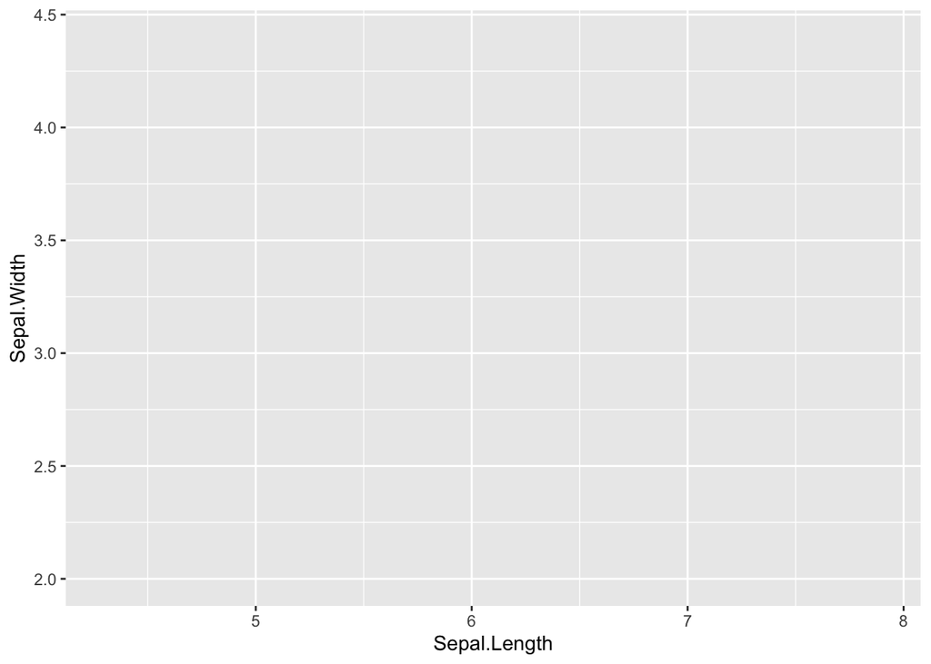

```r
# iris is pass to the first parameter `data` and `aes` is passed to mapping.
# We haven't told ggplot to make a plot yet, so it will appear blank, but
# the templating is here
iris %>%
  ggplot(aes(x = Sepal.Length, y = Sepal.Width, color = Species))
```

## Section 5.2 A sampling of ggplot

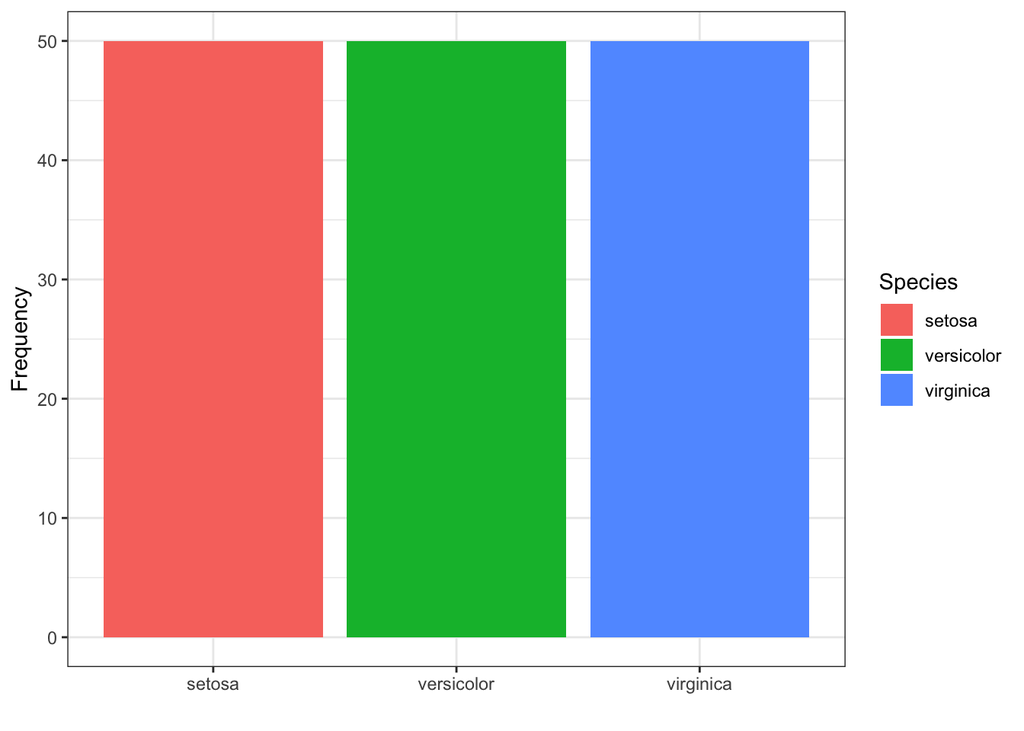

```r
# Bar plot with labels renamed
ggplot(iris, aes(x = Species, fill = Species)) +
  geom_bar() +
  theme_bw() +
  xlab("") +
  ylab("Frequency")
```

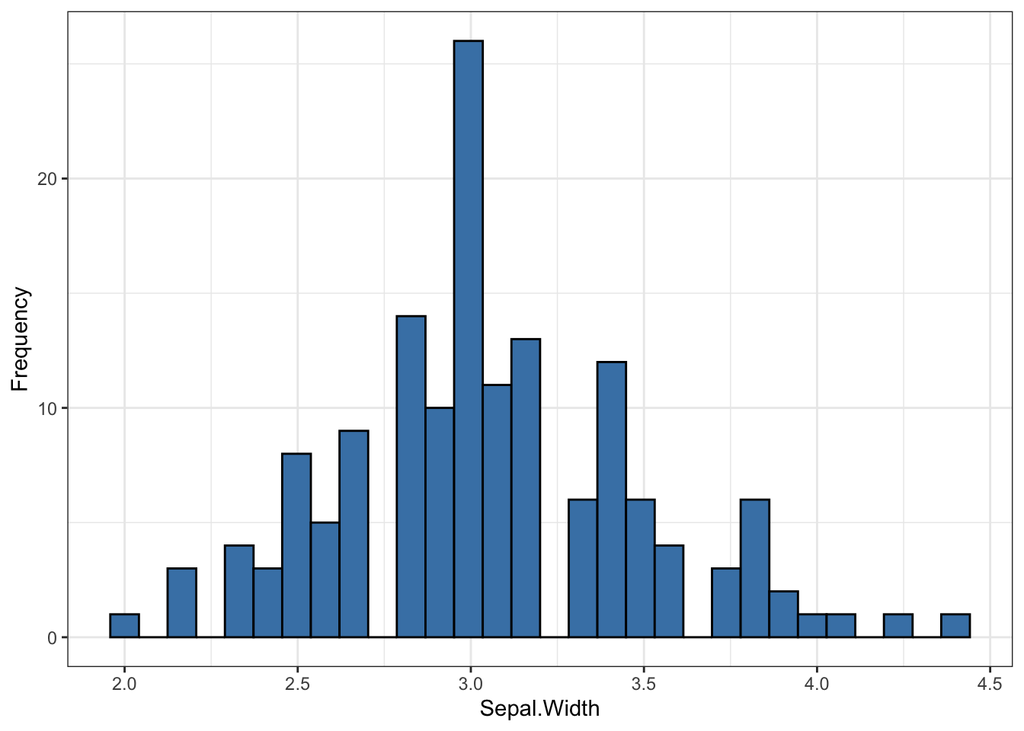

```r
# Histogram
ggplot(iris, aes(x = Sepal.Width)) +
  geom_histogram(color = "black", fill = "steelblue") +
  theme_bw() +
  xlab("Sepal.Width") +
  ylab("Frequency")
```

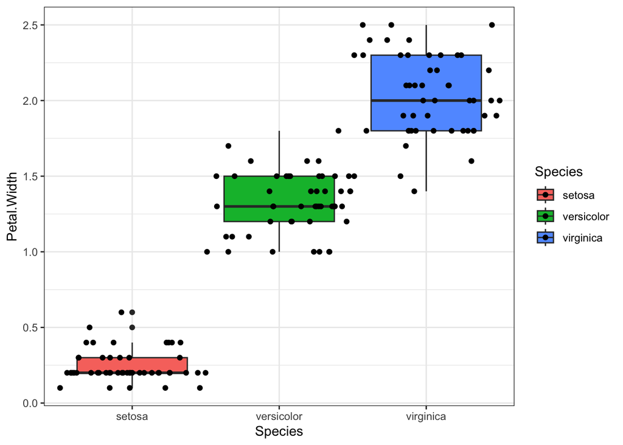

```r
# Boxplot with points. Yes, plot features can stack
ggplot(iris, aes(x = Species, y = Petal.Width, fill = Species)) +
  geom_boxplot() +
  geom_jitter(width = 0.5, height = 0) +
  theme_bw()
```

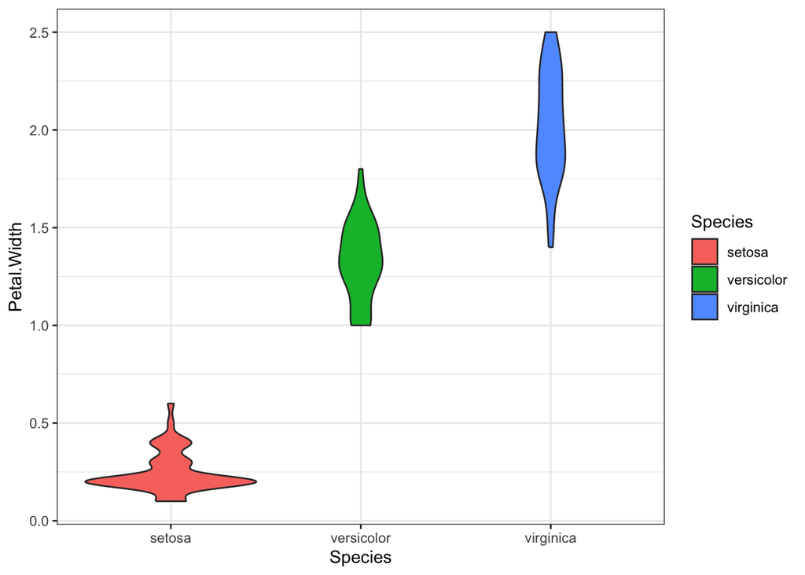

```r
# Violin plots
ggplot(iris, aes(x = Species, y = Petal.Width, fill = Species)) +
  geom_violin() +
  theme_bw()
```

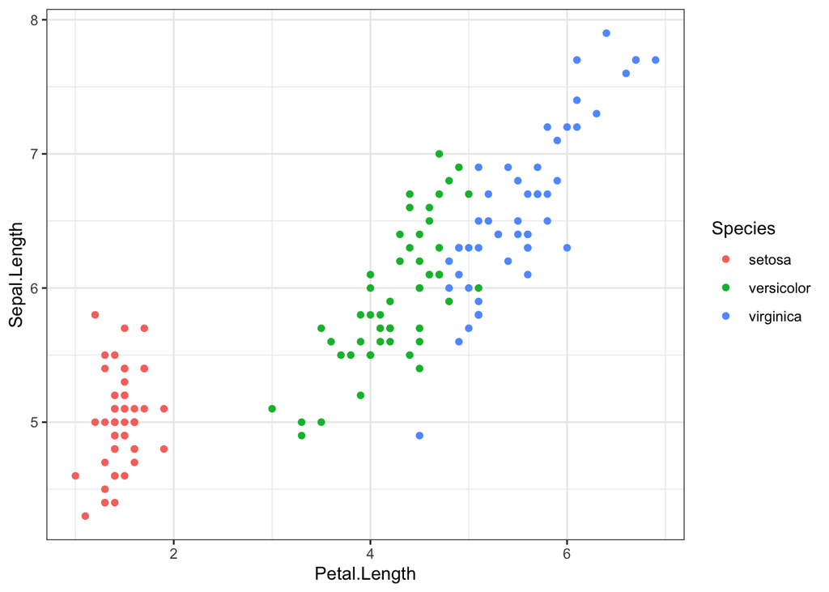

```r
# Scatterplots
ggplot(iris, aes(x = Petal.Length, y = Sepal.Length, color = Species)) +
  geom_point() +
  theme_bw()
```

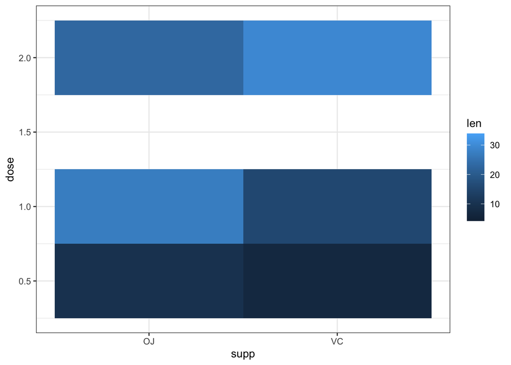

```r
# Heatmaps
ggplot(ToothGrowth, aes(x = supp, y = dose, fill = len)) +
  geom_tile() +
  theme_bw()
```

## Section 5.3 Advanced Plotting Options

Other notes:

- If you have several plots of the same type to make, try `facet_wrap()` and `facet_grid()`
- Make any plot interactive with plotly’s `ggplotly()` function
- If you have several plots of different types to put together, try the `patchwork` package.

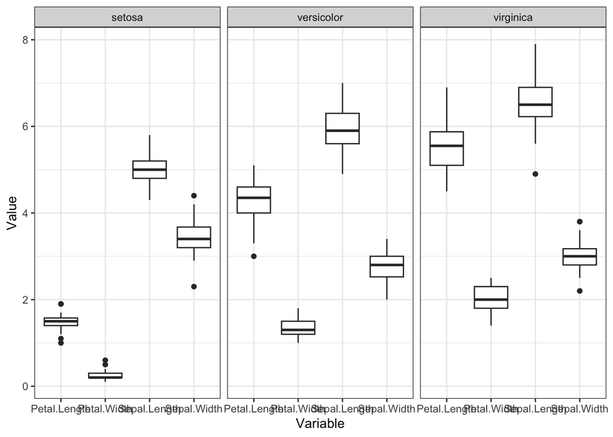

```r
# Facet wrap example
iris %>% pivot_longer(1:4) %>%
  rename(Variable = name, Value = value) %>%
  ggplot(aes(x = Variable, y = Value)) +
  geom_boxplot() +
  theme_bw() +
  facet_wrap(~Species)
```

# R Lecture 6: Functions and Iteration

Sometimes basic vectorized functions in R are not sophisticated enough for some of the more advanced iteration tasks. Though R does support for and while loops, we tend to steer R users to the `purrr` package, as for loops in R can be quite slow. Sticking to use tidyverse in R will like result in fast and clean code, and is our recommendation. Regardless, here we have an example of for loops, and some of the functionality available in purrr.

## Section 6.1 Defining a function

Define a function as so:

```r
myfun = function(x, y) {
  x ** y
}

myfun(3, 2)
```

```
## [1] 9
```

```r
myfun(4, 3)
```

```
## [1] 64
```

## Section 6.2 Iteration with For Loop

Let’s take the mean of a thousand random samples from the normal distribution. `rnorm()` allows us to simulate values from a normal distribution with mean 0 and a standard deviation of 1. `rnorm(100)` will simulate a hundred of these values.

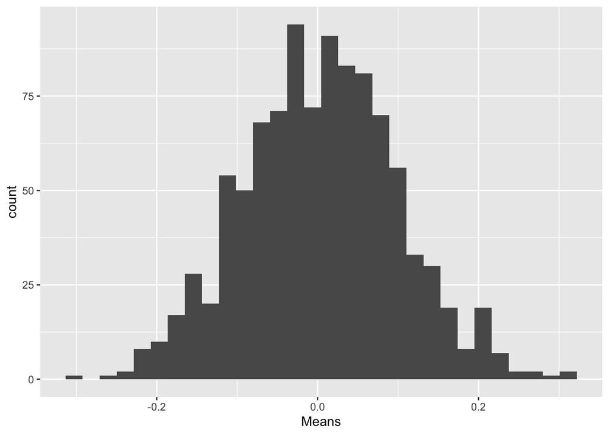

```r
# Set a place to hold the mean values
means = c()

# Iterate a thousand times
for (i in 1:1000) {
  means = c(means, mean(rnorm(100))) # rnorm 100 simulates a 100
}

data.frame(Means = means) %>%
  ggplot(aes(x = Means)) +
    geom_histogram()
```

## Section 6.3 Using purrr

Let’s do this example again, but let’s say instead I want to keep all the simulated values.

```r
# Make a data.frame to hold simulations
simulations = data.frame(Simulations = 1:1000)

# Now let's output all the files as list that we will nest in our data.frame
simulations = simulations %>%
  mutate(Values = map(Simulations, ~rnorm(100)))

# Let's look at the first row
simulations[1,]
```

```
##   Simulations
## 1           1
##                                                                                                                                                                                                                                                                                                          …
## 1 -0.294165985, 2.380335207, -0.210931661, 0.528917814, 1.235058593, 0.083183306, -0.173942577, -0.459272653, 0.305058125, -0.079771105, -0.250856887, -1.079503591, 0.486715283, 0.359440032, -0.847202569, -1.137615965, 0.843240472, -0.035781576, 0.616935995, -0.593598510, 0.805660340, -0.04066489…
```

```r
# Now let's calculate the mean of each of these groups. map_dbl
# will return a single value for each row as opposed to map which
# returns a list. See the other map function `map_lgl`, `map_chr`,
# etc to return logicals, character, etc
simulations = simulations %>%
  mutate(mean = map_dbl(Values, function(x) {mean(x)}))

simulations[1,]
```

```
##   Simulations
## 1           1
##                                                                                                                                                                                                                                                                                                          …
## 1 -0.294165985, 2.380335207, -0.210931661, 0.528917814, 1.235058593, 0.083183306, -0.173942577, -0.459272653, 0.305058125, -0.079771105, -0.250856887, -1.079503591, 0.486715283, 0.359440032, -0.847202569, -1.137615965, 0.843240472, -0.035781576, 0.616935995, -0.593598510, 0.805660340, -0.04066489…
##         mean
## 1 0.07318975
```

```r
# If we want everything as a single value list, we can use tidyr::unnest.
simulations %>%
  unnest(cols = Values) %>%
  head()
```

```
## # A tibble: 6 × 3
##   Simulations  Values   mean
##         <int>   <dbl>  <dbl>
## 1           1 -0.294  0.0732
## 2           1  2.38   0.0732
## 3           1 -0.211  0.0732
## 4           1  0.529  0.0732
## 5           1  1.24   0.0732
## 6           1  0.0832 0.0732
```

```r
# Similarly, we can use group_by() and nest() to make groups to iterate through.
# This is useful for functions that are much more complicated than the mean used
# here.
iris %>%
  group_by(Species) %>%
  nest() %>%
  mutate(mean = map_dbl(data, function(x) {mean(x$Sepal.Width)})) %>%
  select(-data)
```

```
## # A tibble: 3 × 2
## # Groups:   Species [3]
##   Species     mean
##   <fct>      <dbl>
## 1 setosa      3.43
## 2 versicolor  2.77
## 3 virginica   2.97
```

# Wrap-Up

This is the end of the introduction to R tutorials! To continue your learning, open R and RStudio, and start working through examples in these excellent resources:

- [R Cookbook](https://rc2e.com/)
- [R for Data Science](https://r4ds.had.co.nz/)
- [Advanced R](https://adv-r.hadley.nz/)
- [Tidymodels](https://www.tmwr.org/)